# Assignment 2

Anastasiia Andreeva

11/22/2020

```r
setwd("/Users/pirozhok/Desktop/OneDrive - Central European University/FALL2020/intermeditequants/Assignment 2")
CCES19_assignment <- read.csv("/Users/pirozhok/Desktop/OneDrive - Central European University/FALL2020/intermeditequants/Assignment 2/CCES19_assignment.csv")
```

In order to optimize further work with the data, I will omit the missing values from the dataset:

```r
CCES19_assignment = na.omit(CCES19_assignment)
```

# Exercise 1.1

*Create an index of sexism, racism and immigration preferences using the corresponding survey items. Describe their distribution. To do so, identify which variables can be used to measure sexism, racism, and immigration, respectively. Then, calculate the index by averaging these variables. Be careful here! The scales need to be the same before you average. This means that if for one variable the maximum denotes a given attitude and for another, the minimum denotes that attitude, you need to reverse one of the scales scale.*

## Sexism

To create an index of respondents’ preferences in regards to sexism I am going to use two variables. The first is CC19_343d. This variable demonstrates the attitude of people towards the statement ‘Feminists make reasonable demands’ on a scale from 1 to 5, where 1 - strongly agree and 5 - strongly disagree.

```r
summary(CCES19_assignment$CC19_343d)
```

```
##    Min. 1st Qu.  Median    Mean 3rd Qu.    Max.
##   1.000   2.000   3.000   2.951   4.000   5.000
```

The second variable is CC19_343c. Here, the respondents indicated their attitude towards the statement: ‘Women complain about being discriminated’ on the same 1 to 5 scale.

```r
summary(CCES19_assignment$CC19_343c)
```

```
##    Min. 1st Qu.  Median    Mean 3rd Qu.    Max.
##   1.000   2.000   3.000   2.974   4.000   5.000
```

Those statements are polar opposites to each other, so, in order to generate the index, I will flip one of the variables - CC19_343d - the one that indicated that feminists’ claims are fair. So, in the final index of attitudes towards sexism 1 is going to indicate a strong sexist attitude and 5 is going to indicate strong non-sexist attitude.

```r
CCES19_assignment$CC19_343d_flip = rep(length(CCES19_assignment$CC19_343d))
for(i in 1:length(CCES19_assignment$CC19_343d)){
  if (is.na(CCES19_assignment$CC19_343d[i]) == FALSE){
    if (CCES19_assignment$CC19_343d[i] == 1){
      CCES19_assignment$CC19_343d_flip[i] = 5
    }
    else if (CCES19_assignment$CC19_343d[i] == 2){
      CCES19_assignment$CC19_343d_flip[i] = 4
    }
    else if (CCES19_assignment$CC19_343d[i] == 3){
      CCES19_assignment$CC19_343d_flip[i] = 3
    }
    else if (CCES19_assignment$CC19_343d[i] == 4){
      CCES19_assignment$CC19_343d_flip[i] = 2
    }
    else if (CCES19_assignment$CC19_343d[i] == 5){
      CCES19_assignment$CC19_343d_flip[i] = 1
    }
  }
}
```

Now that one of the variables is flipped and scores of both of the variables are comparable, I will create a new variable - sexism, which is going to indicate the mean of two analyzed variables.

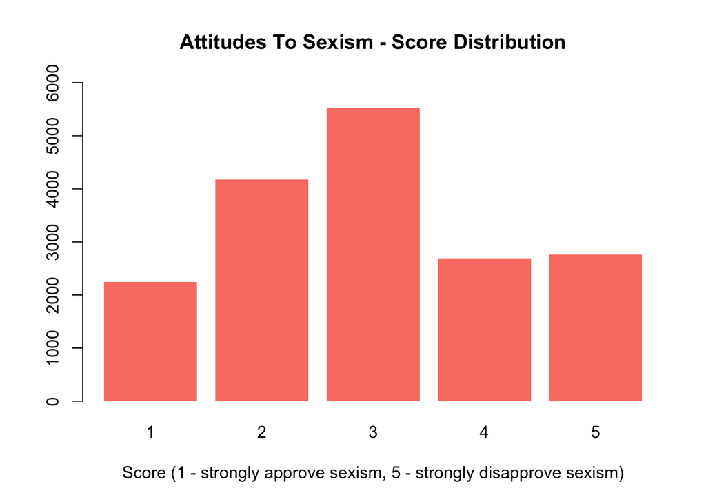

```r
CCES19_assignment$sexism = rep(length(CCES19_assignment$CC19_343d))
for(i in 1:length(CCES19_assignment$sexism)){
    CCES19_assignment$sexism[i] = mean(CCES19_assignment$CC19_343c[i],
                                       CCES19_assignment$CC19_343d_flip[i])
  }

sexismindex<-table(CCES19_assignment$sexism)
barplot(sexismindex, ylim=c(0,6000),
     main="Attitudes To Sexism - Score Distribution",
     xlab="Score (1 - strongly approve sexism, 5 - strongly disapprove sexism)",
     cex.lab = 1,
     cex.axis = 1,
     col="salmon",
     border=NA)
```

We can see that most respondents do not have any strong feelings about sexist statements (as most people chose the middle score - 3, which was framed as ‘Neither agree nor disagree’). Though, slightly more people tend to approve, rather than to disapprove them - the frequency of scores 1 and 2 are notably higher than the frequency of 4 and 5.

## Racism

I am going to follow the similar steps in creating the index for racism. Again, I am using two variables. The first one - CC19_343a, which indicates the respondents attitude toward the following statement: ‘White people have certain advantages’ (1 - strongly agree, 5 - strongly disagree).

```r
summary(CCES19_assignment$CC19_343a)
```

```
##    Min. 1st Qu.  Median    Mean 3rd Qu.    Max.
##   1.000   1.000   2.000   2.622   4.000   5.000
```

The second variable that I am going to use for this index is CC19_343b - ‘Racial problems are rare, isolated’. I am going to flip the values of the first variable, so it is going to be comparable with the values of the second variable.

```r
summary(CCES19_assignment$CC19_343b)
```

```
##    Min. 1st Qu.  Median    Mean 3rd Qu.    Max.
##   1.000   3.000   4.000   3.627   5.000   5.000
```

```r
CCES19_assignment$CC19_343a_flip = rep(length(CCES19_assignment$CC19_343a))
for(i in 1:length(CCES19_assignment$CC19_343a)){
  if (is.na(CCES19_assignment$CC19_343a[i]) == FALSE){
    if (CCES19_assignment$CC19_343a[i] == 1){
      CCES19_assignment$CC19_343a_flip[i] = 5
    }
    else if (CCES19_assignment$CC19_343a[i] == 2){
      CCES19_assignment$CC19_343a_flip[i] = 4
    }
    else if (CCES19_assignment$CC19_343a[i] == 3){
      CCES19_assignment$CC19_343a_flip[i] = 3
    }
    else if (CCES19_assignment$CC19_343a[i] == 4){
      CCES19_assignment$CC19_343a_flip[i] = 2
    }
    else if (CCES19_assignment$CC19_343a[i] == 5){
      CCES19_assignment$CC19_343a_flip[i] = 1
    }
  }
}
```

The variable is flipped, and now I am going to create a new variable - racism, which is going to reflect the mean of the two values described above.

```r
CCES19_assignment$racism = rep(length(CCES19_assignment$CC19_343a))
for(i in 1:length(CCES19_assignment$racism)){
    CCES19_assignment$racism[i] = mean(CCES19_assignment$CC19_343b[i],
                                       CCES19_assignment$CC19_343a_flip[i])
  }
```

Now let’s take a look at the distribution:

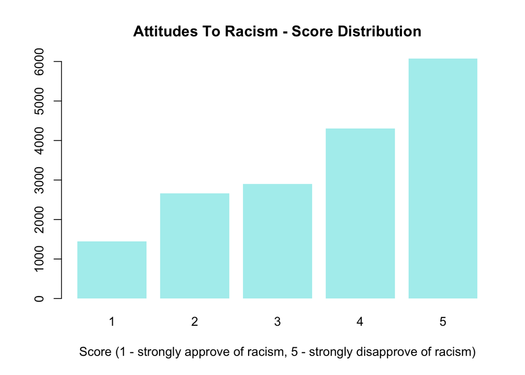

```r
racismindex<-table(CCES19_assignment$racism)
barplot(racismindex, ylim=c(0,6000),
        main="Attitudes To Racism - Score Distribution",
        xlab="Score (1 - strongly approve of racism, 5 - strongly disapprove of racism)",
        cex.lab = 1,
        cex.axis = 1,
        col="paleturquoise",
        border=NA)
```

```r
summary(CCES19_assignment$racism)
```

```
##    Min. 1st Qu.  Median    Mean 3rd Qu.    Max.
##   1.000   3.000   4.000   3.627   5.000   5.000
```

## Immigration

Finally, I will generate a similar index for respondents attitudes towards legal status of immigrants. There are quite a few variables that are tackling the issue of immigration, but I am going to pick just two, that have an opposing meaning, so one of them could be flipped easily to create an immigration index. Here are the variables that I am going to work with: 1. CC19_322c - Reduce legal immigration by 50 percent. 2. CC19_322d - Grant legal status to all illegal immigrants who have held jobs and paid taxes for at least 3 years, and not been convicted of any felony crimes. I am going to flip the second variable. This index is a little bit different then the two previous ones, because instead of 5-level score, respondents were could chose one of two options - ‘Support’ and ‘Oppose’.

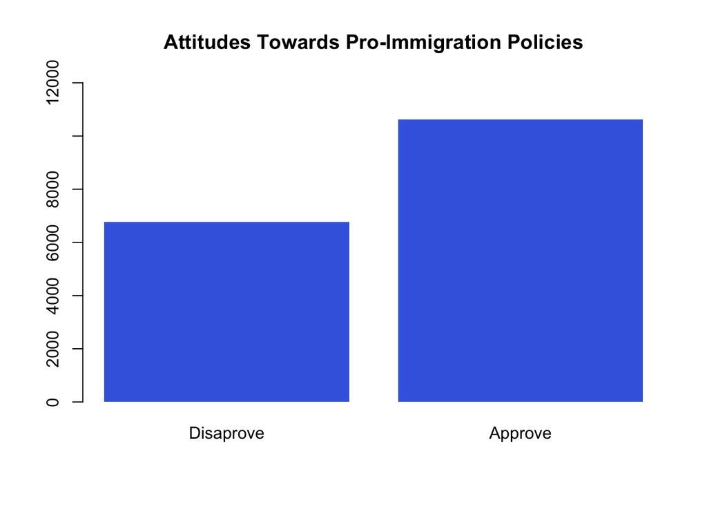

```r
CCES19_assignment$CC19_322d_flip = rep(length(CCES19_assignment$CC19_322d))
for(i in 1:length(CCES19_assignment$CC19_322d)){
  if (is.na(CCES19_assignment$CC19_322d[i]) == FALSE){
    if (CCES19_assignment$CC19_322d[i] == 1){
      CCES19_assignment$CC19_322d_flip[i] = 2
    }
    else if (CCES19_assignment$CC19_322d[i] == 2){
      CCES19_assignment$CC19_322d_flip[i] = 1
    }
  }
}

CCES19_assignment$immigration = rep(length(CCES19_assignment$CC19_322d))
for(i in 1:length(CCES19_assignment$immigration)){
    CCES19_assignment$immigration[i] = mean(CCES19_assignment$CC19_322c[i],
                                       CCES19_assignment$CC19_322d_flip[i])
}

immigrationindex<-table(CCES19_assignment$immigration)
barplot(immigrationindex, ylim=c(0,12000),
        main="Attitudes Towards Pro-Immigration Policies",
        cex.lab = 1,
        cex.axis = 1,
        col="royalblue",
        names.arg=c("Disaprove", "Approve"),
        border=NA)
```

We can see that more than half of the respondents approve the pro-immigration policies. We can also see it by looking at the mean of the variable.

```r
summary(CCES19_assignment$immigration)
```

```
##    Min. 1st Qu.  Median    Mean 3rd Qu.    Max.
##   1.000   1.000   2.000   1.611   2.000   2.000
```

# Exercise 1.2

*How does the distribution of sexism vary across men and women? Illustrate the difference by plotting the distributions for each category.*

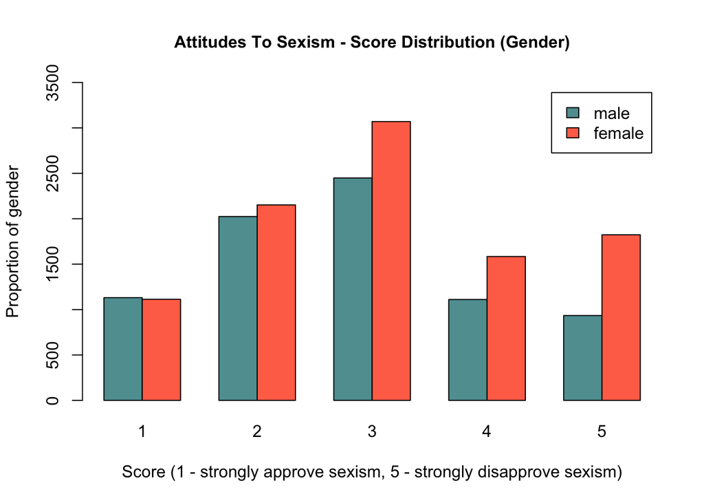

```r
sexism.mw<-table(CCES19_assignment$gender, CCES19_assignment$sexism)
barplot(sexism.mw, beside=TRUE, legend=c("male", "female"),
        main="Attitudes To Sexism - Score Distribution (Gender)",
        cex.main=1,
        xlab="Score (1 - strongly approve sexism, 5 - strongly disapprove sexism)",
        ylab="Proportion of gender",
        ylim=c(0,3500),
        col=c("cadetblue", "coral1"))
```

Generally, the distribution of sexism disapproval score is rather similar in both men and women - most respondents of both genders tend to choose the middle option - neither approve or disapprove of sexism. On the barplots we can vividly see that more women than men have a strong anti-sexism position, so the distribution on the right side of the bar plot is higher for women, than for men.

We can also see that by looking at the mean of the distribution of frequency of the scores, which is a measure sensitive to extreme values. Whereas the median is the same for both men and women, but the mean is noticeably higher for women.

```r
men <- subset(CCES19_assignment, subset = (gender==1))
women <- subset(CCES19_assignment, subset =(gender==2))
summary(men$sexism)
```

```
##    Min. 1st Qu.  Median    Mean 3rd Qu.    Max.
##   1.000   2.000   3.000   2.829   4.000   5.000
```

```r
summary(women$sexism)
```

```
##    Min. 1st Qu.  Median    Mean 3rd Qu.    Max.
##   1.000   2.000   3.000   3.087   4.000   5.000
```

# Exercise 1.3

*How does the distribution of racism vary across racial/ethnic groups? How would you interpret this? Illustrate the difference by plotting the distributions for each category.*

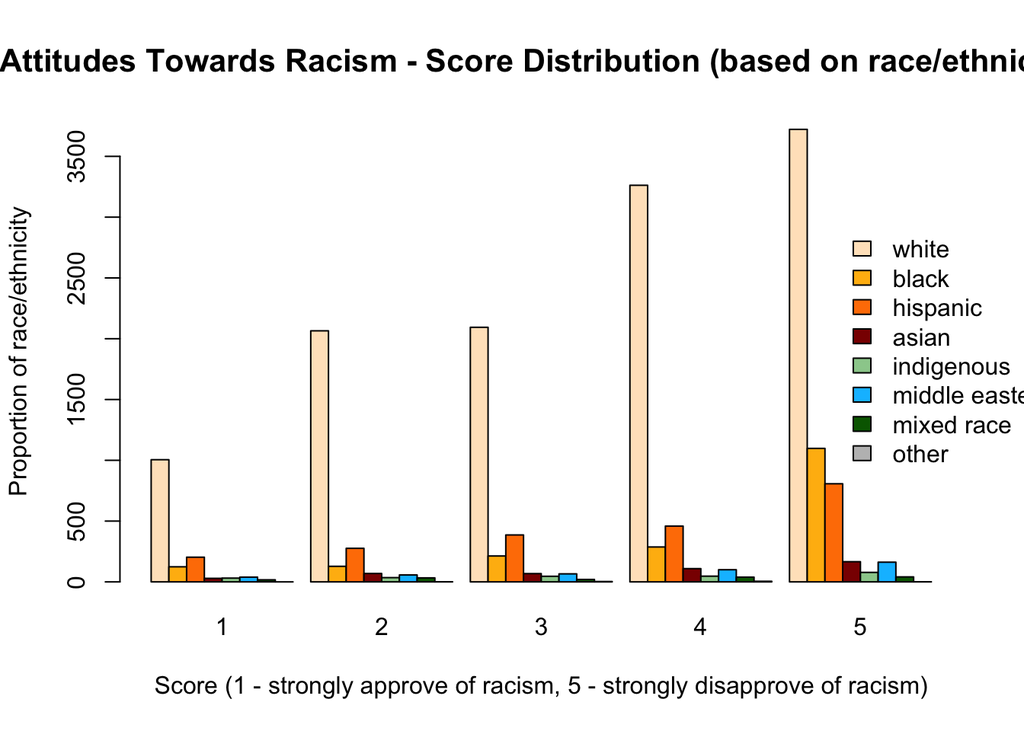

```r
racism.dist<-table(CCES19_assignment$race, CCES19_assignment$racism)
barplot(racism.dist, beside=TRUE,
        legend=c("white", "black", "hispanic", "asian", "indigenous", "middle eastern", "mixed race", "other"),
        args.legend = list(x ="right", bty="n", inset=c(-0.12,0), xpd = TRUE),
        main="Attitudes Towards Racism - Score Distribution (based on race/ethnicity)",
        cex.main=1.3,
        xlab="Score (1 - strongly approve of racism, 5 - strongly disapprove of racism)",
        ylab="Proportion of race/ethnicity",
        ylim=c(0,3800),
        col=c("bisque", "darkgoldenrod1", "darkorange1", "darkred", "darkseagreen3", "deepskyblue", "darkgreen", "gray"))
```

Respondents of all races and ethnicities tend to be strongly disapproval of racism, rather than being undecided or to be approve of it, though the distribution is less steep for white people. We can also see a significantly bigger share of people of color in ‘Disapprove’ and ‘Disapprove strongly’ categories (score 4 and 5), then in approval categories. Another interesting trend that we can see on the barplot is the distribution of frequencies among black and hispanic respondents in comparison. As any other respondents, most of them tend to be strongly disapprove of racism, but there are significantly more hispanic survey-takers that do not oppose racism strongly.

# Exercise 1.4

*How does the extent of anti-immigration sentiment vary across states? List the top 5 and bottom 5 states and comment on their geographical pattern!*

For this exercise, I will have to work with 5 variables, that identify the attitudes of respondents towards immigration. To begin with, I will have to flip one of the variables - CC19_322a ‘Overturn President Trump’s order to use $6 billion of defense funds to pay for the construction of a wall.’, so the values of all of the five analyzed variables would have the same meaning: if the respondent is choosing option 1, it means that their attitude is rather anti-immigrant and if they choose 2, they are rather pro-immigrant. Another variable, CC19_322d - ‘Grant legal status to all illegal immigrants who have held jobs and paid taxes for at least 3 years, and not been convicted of any felony crimes.’ has already been flipped in the exercise 1.1. Values of another three variables are in line with the meaning of 1=anti-immigrant attitude, 2=pro-immigrant attitude.

```r
CCES19_assignment$CC19_322a_flip = rep(length(CCES19_assignment$CC19_322a))
for(i in 1:length(CCES19_assignment$CC19_322a)){
  if (is.na(CCES19_assignment$CC19_322a[i]) == FALSE){
    if (CCES19_assignment$CC19_322a[i] == 1){
      CCES19_assignment$CC19_322a_flip[i] = 2
    }
    else if (CCES19_assignment$CC19_322a[i] == 2){
      CCES19_assignment$CC19_322a_flip[i] = 1
    }
  }
  }
```

In order to create an overall index, it will be much easier, if the variables are going to be coded with values 0 and 1, instead of 1 and 2. To keep the code less chunky and make further code easier, I will only replace the value 2 in each variable with a 0. So the meaning of the values of the immigration-related variables will be the following:

0 - if the respondent indicates pro-immigrant attitude;  
1 - if the respondent indicates anti-immigrant attitude.

```r
for(i in 1:length(CCES19_assignment$CC19_322a_flip)){
  if (CCES19_assignment$CC19_322a_flip[i] == 2){
    CCES19_assignment$CC19_322a_flip[i] = 0
}
}
for(i in 1:length(CCES19_assignment$CC19_322b)){
  if (is.na(CCES19_assignment$CC19_322b[i]) == FALSE){
  if (CCES19_assignment$CC19_322b[i] == 2){
    CCES19_assignment$CC19_322b[i] = 0
  }
  }
}
for(i in 1:length(CCES19_assignment$CC19_322c)){
  if (is.na(CCES19_assignment$CC19_322c[i]) == FALSE){
  if (CCES19_assignment$CC19_322c[i] == 2){
    CCES19_assignment$CC19_322c[i] = 0
  }
  }
}
for(i in 1:length(CCES19_assignment$CC19_322d_flip)){
  if (is.na(CCES19_assignment$CC19_322d_flip[i]) == FALSE){
  if (CCES19_assignment$CC19_322d_flip[i] == 2){
    CCES19_assignment$CC19_322d_flip[i] = 0
  }
  }
}
for(i in 1:length(CCES19_assignment$CC19_322e)){
  if (is.na(CCES19_assignment$CC19_322e[i]) == FALSE){
  if (CCES19_assignment$CC19_322e[i] == 2){
    CCES19_assignment$CC19_322e[i] = 0
  }
  }
}
```

Now, I will store the average value of these five variables for each of the observations in a separate variable:

```r
a = CCES19_assignment[,c(9, 10, 12, 23, 24)]
CCES19_assignment$migr_avg<-rowMeans(a, na.rm = FALSE, dims = 1)
```

Then I am going to calculate the average value for every state:

```r
library(plyr)
b = ddply(CCES19_assignment, .(inputstate), summarise, mean(migr_avg))
names(b)[names(b) == "..1"] <- "avg.immigr"
```

"I tried using dplyr’s arrange() function (and also head() and tail()) to print top-5 and bottom-5 states, but it did not run properly, unfortunately, so I checked the results manually, by opening the data and filtering ‘avg.immigr’ variable from highest to lowest and vice versa. Top-5 states with highest anti-immigrant sentiment:  
1. Idaho.  
2. South Dakota.  
3. Mississippi.  
4. West Virginia.  
5. Tennessee.

Bottom-5 states with lowest anti-immigrant sentiment:  
1. Vermont.  
2. District of Colombia.  
3. Hawaii.  
4. Washington.  
5. New York.

# Exercise 1.5

*Calculate the average of sexism by age and gender and compute the gender difference in sexism for 4 quartiles of the sample by age. Visualize and interpret your findings!*

First, I will create the variable age, as the initial dataset only has the variable that indicates the birth year of the respondents.

```r
CCES19_assignment$age <- 2019 - CCES19_assignment$birthyr
summary(CCES19_assignment$age)
```

```
##    Min. 1st Qu.  Median    Mean 3rd Qu.    Max.
##   18.00   34.00   51.00   49.26   63.00  100.00
```

Now I can see the values of the age quartiles, so I can generate the following variable indicating that:

```r
CCES19_assignment$age.quart <- NA
CCES19_assignment$age.quart[CCES19_assignment$age <= 34] <- 1
CCES19_assignment$age.quart[CCES19_assignment$age > 34 & CCES19_assignment$age <= 49.26] <- 2
CCES19_assignment$age.quart[CCES19_assignment$age > 49.26 & CCES19_assignment$age<=63] <- 3
CCES19_assignment$age.quart[CCES19_assignment$age > 63] <- 4
```

Then I am going yo calculate the average of sexism by age quartiles and gender:

```r
library(plyr)
c = ddply(CCES19_assignment, .(age.quart, gender), summarise, mean(sexism))
```

Finally, I am going to calculate the gender difference for age quartiles (to do that, I will use cast function, which will efficiently summarize the variables:

```r
library(reshape2)
c_L_to_W = dcast(c, age.quart~gender,sum)
```

I am renaming the variables, and it might not seem neccesary, but R treats the names of the variables 1 and 2 as numbers and does not want to run the further code.

```r
names(c_L_to_W)[names(c_L_to_W) == "1"] <- "male"
names(c_L_to_W)[names(c_L_to_W) == "2"] <- "female"
c_L_to_W$diff = c_L_to_W$female - c_L_to_W$male
head(c_L_to_W$diff)
```

```
## [1] 0.1621424 0.2227612 0.2895057 0.2930234
```

By looking at the differences in age quartiles among male and female respondents, we can see that the difference in attitudes towards sexism is almost twice as bigger for older people, than for younger. Also, in all of the age categories women are more disapprove of sexism, than men. Interestingly, especially in older women seem to tend to share rather anti-sexist views, unlike the men their age. Conversely, among yonger people (the first age quartile), the difference between men and women is nearly twice as small. So, I can conclude that generally gender equality values and principles are getting widely picked up among young people - both among men and women. Whereas, for older generations it is rather more women than men who share that values. Now, I will plot the differences between men and women’s attitudes towards sexism based on their age.

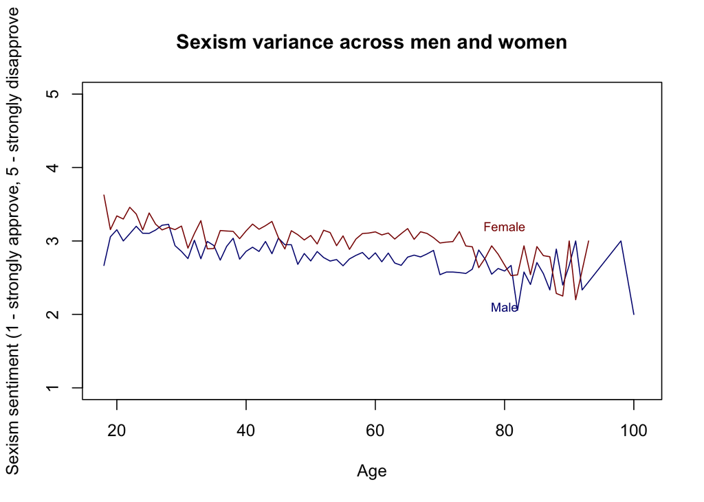

```r
library(plyr)
age.gender <- ddply(CCES19_assignment, .(age, gender), summarise, mean(sexism, na.rm = T))
names(age.gender)[3]<-"mean"
age.gender.m<-subset(age.gender, subset=(gender==1))
age.gender.f<-subset(age.gender, subset=(gender==2))
plot(age.gender.m$age, age.gender.m$mean, col = "white",
     ylim = c(1,5), xlim = c(18,101),
     xlab = "Age", ylab = "Sexism sentiment (1 - strongly approve, 5 - strongly disapprove",
     main = "Sexism variance across men and women")
lines(age.gender.m$age, age.gender.m$mean, col = "navyblue")
lines(age.gender.f$age, age.gender.f$mean, col = "darkred")
text(80, 2.1, "Male", col = "navyblue", cex = 0.75)
text(80, 3.2, "Female", col = "darkred", cex = 0.75)
```

The visualization shows us a more detailed overview of score distributions. Firstly, we can see that there are clear differences between men’s and women’s attitudes towards sexism in the age group around 50-70 (women tending oppose sexism strongly). For younger and older people that difference is not that clear - we see that in that age groups the two lines are overlapping a lot. Also we can see that young people in general tend to be more anti-sexist than older people.

# Exercise 1.6

*Use the ddply function to calculate the correlation between sexism and racism by education.*

I am going to calculate correlation between sexism and racism by six groups - levels of education, where 1 is the lowest level of education - ‘Did not graduate from high school’, and 6 is the highest level - ‘Has a postgraduate degree’.

```r
library(plyr)
d = ddply(CCES19_assignment, .(educ), summarise, cor(sexism, racism, use = "complete.obs"))
names(d)[names(d) == "..1"] <- "sexism_racism_cor"
head(d)
```

|  | educ | sexism_racism_cor |
| --- | --- | --- |
| 1 | 1 | 0.2583619 |
| 2 | 2 | 0.3122081 |
| 3 | 3 | 0.3430944 |
| 4 | 4 | 0.3635491 |
| 5 | 5 | 0.4654051 |
| 6 | 6 | 0.5045889 |

# Exercise 2.1

*Recode CC19308a by placing people saying “not sure” in a middle category. Show the results by summarizing the proportions in a table and barplot.*

I am going to use the loop to change the values of the variable. Before running the loop, the analyzing scale represents the following:

1 - Strongly approve.  
2 - Somewhat approve.  
3 - Somewhat disapprove.  
4 - Strongly disapprove.  
5 - Not sure.  
I will replace 3 with 4, 4 with 5 and 5 with 3.

```r
summary(CCES19_assignment$CC19_308a)
```

```
##    Min. 1st Qu.  Median    Mean 3rd Qu.    Max.
##   1.000   1.000   4.000   2.849   4.000   5.000
```

```r
CCES19_assignment$CC19_308a_repl = rep(length(CCES19_assignment$CC19_308a))
for(i in 1:length(CCES19_assignment$CC19_343a)){
  if (CCES19_assignment$CC19_308a[i] == 1){
    CCES19_assignment$CC19_308a_repl[i] = 1
  }
  else if (CCES19_assignment$CC19_308a[i] == 2){
    CCES19_assignment$CC19_308a_repl[i] = 2
  }
  else if (CCES19_assignment$CC19_308a[i] == 3){
    CCES19_assignment$CC19_308a_repl[i] = 4
  }
  else if (CCES19_assignment$CC19_308a[i] == 4){
    CCES19_assignment$CC19_308a_repl[i] = 5
  }
  else if (CCES19_assignment$CC19_308a[i] == 5){
    CCES19_assignment$CC19_308a_repl[i] = 3
  }
}
summary(CCES19_assignment$CC19_308a_repl)
```

```
##    Min. 1st Qu.  Median    Mean 3rd Qu.    Max.
##   1.000   1.000   4.000   3.346   5.000   5.000
```

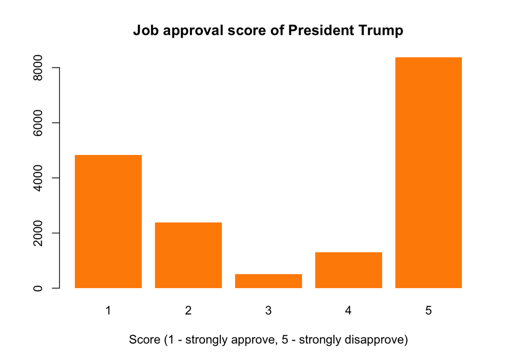

```r
trump_approv <- table(CCES19_assignment$CC19_308a_repl)
barplot(trump_approv, ylim=c(0,8300),
        main="Job approval score of President Trump",
        xlab="Score (1 - strongly approve, 5 - strongly disapprove)",
        cex.lab = 1,
        cex.axis = 1,
        col="darkorange",
        border=NA)
```

# Exercise 2.2

*Run a simple regression predicting approval of Trump by anti immigration preferences. Interpret your findings!*

```r
migr_trump <- lm(CC19_308a_repl ~ migr_avg, data = CCES19_assignment)
summary(migr_trump)
```

```
##
## Call:
## lm(formula = CC19_308a_repl ~ migr_avg, data = CCES19_assignment)
##
## Residuals:
##     Min      1Q  Median      3Q     Max
## -4.0144 -0.6302 -0.0144  1.1136  3.3698
##
## Coefficients:
##             Estimate Std. Error t value Pr(>|t|)
## (Intercept)  7.27057    0.03112   233.7   <2e-16 ***
## migr_avg    -5.64035    0.04260  -132.4   <2e-16 ***
## ---
## Signif. codes:  0 '***' 0.001 '**' 0.01 '*' 0.05 '.' 0.1 ' ' 1
##
## Residual standard error: 1.248 on 17389 degrees of freedom
## Multiple R-squared:  0.502,  Adjusted R-squared:  0.502
## F-statistic: 1.753e+04 on 1 and 17389 DF,  p-value: < 2.2e-16
```

Finally, let’s take a look at the coefficient.

-5.6403469

We can see that there is a negative correlation between dependent and independent variable. It means that one unit increase in anti-immigration sentiment index leads to 5 point decrease in Trump job approval rating. So the higher the level of anti-immigrant sentiment, the lower would be the disapproval of Trump (just to recall the job approval score - 1 indicated strong approval of Trump and 5 indicated strong disapproval). To put it all in a very simple sentence: we can certainly say that higher level of anti-immigration preferences is a valid predictor of stronger approval of President Trump.

# Exercise 2.3

*Run a regression predicting approval of Trump by racism. Repeat this exercise separately for Whites, Blacks and Hispanics. How do the regression coefficients compare? Explain!*  
Running a regression predicting approval of Trump by racism:

```r
racism_trump <- lm(CC19_308a_repl ~ racism, data = CCES19_assignment)
```

Subsetting the data to run subgroup regressions:

```r
racism_white <- subset(CCES19_assignment, subset = (race==1))
racism_black <- subset(CCES19_assignment, subset = (race==2))
racism_hispanic <- subset(CCES19_assignment, subset = (race==3))
```

Running regressions for Whites, Blacks and Hispanics:

```r
racism_trump_white <- lm(CC19_308a_repl ~ racism, data = racism_white)
racism_trump_black <- lm(CC19_308a_repl ~ racism, data = racism_black)
racism_trump_hispanic <- lm(CC19_308a_repl ~ racism, data = racism_hispanic)
coef(racism_trump)
```

```
## (Intercept)      racism
##   0.6658043   0.7390560
```

By looking at the regression of Trump approval score and overall racism index, we can see that higher level of Trump disapproval corresponds with higher level of racism disapproval.

```r
coef(racism_trump_white)
```

```
## (Intercept)      racism
##   0.3593171   0.7800120
```

```r
coef(racism_trump_black)
```

```
## (Intercept)      racism
##     3.13743     0.30544
```

```r
coef(racism_trump_hispanic)
```

```
## (Intercept)      racism
##   1.2909316   0.6428603
```

The coefficient is positive for all of the three subgroups, so the positive relationship between higher level of Trump disapproval and higher level of racism disapproval prevails for white, black and hispanic respondents. Though, we can see that the slope of the regression line for white respondents is much steeper than for blacks and hispanics. For whites, 1 unit increase in racism approval score, leads to 0.780012 unit increase in Trump disapproval. Whereas for hispanics it is only 0.6428603 unit increase and it is even lower for blacks - 0.30544.

What does it tell us? For white respondents, anti-racist sentiment is more closely connected to Trump disapproval, than for blacks and hispanics. This is the only conclusion that I can draw from this observation. It is important to point out that it does not mean that white respondents tend to be more anti-racist or more disapprove of Trump, just for that group the slope of regression coefficient is steeper. I would assume that the level of racism and Trump disapproval for blacks and hispanics there are some others predictors that just were not controlled for in this particular model.

# Exercise 2.4

*Run a regression predicting approval of Trump by sexism. Then, run the same regression including two indicators for Republicans and Democrats (based on CC19308a). How do your results change? Explain!*

```r
sexism_trump <- lm(CC19_308a_repl ~ sexism, data = CCES19_assignment)
summary(sexism_trump)
```

```
##
## Call:
## lm(formula = CC19_308a_repl ~ sexism, data = CCES19_assignment)
##
## Residuals:
##     Min      1Q  Median      3Q     Max
## -3.5686 -1.3619  0.4314  1.6381  2.8449
##
## Coefficients:
##             Estimate Std. Error t value Pr(>|t|)
## (Intercept) 1.551765   0.031503   49.26   <2e-16 ***
## sexism      0.603373   0.009774   61.73   <2e-16 ***
## ---
## Signif. codes:  0 '***' 0.001 '**' 0.01 '*' 0.05 '.' 0.1 ' ' 1
##
## Residual standard error: 1.602 on 17389 degrees of freedom
## Multiple R-squared:  0.1798, Adjusted R-squared:  0.1797
## F-statistic:  3811 on 1 and 17389 DF,  p-value: < 2.2e-16
```

Generating dummies for republicans and democrats:

```r
CCES19_assignment$dem[CCES19_assignment$pid3 == 1] <- 1
CCES19_assignment$dem[CCES19_assignment$pid3 != 1] <- 0
CCES19_assignment$rep[CCES19_assignment$pid3 == 2] <- 1
CCES19_assignment$rep[CCES19_assignment$pid3 != 2] <- 0
```

Fitting the model:

```r
sexism_party = lm(CC19_308a_repl ~ sexism + dem + rep, data = CCES19_assignment)
summary(sexism_party)
```

```
##
## Call:
## lm(formula = CC19_308a_repl ~ sexism + dem + rep, data = CCES19_assignment)
##
## Residuals:
##     Min      1Q  Median      3Q     Max
## -4.1716 -0.7495 -0.0628  0.7682  3.8771
##
## Coefficients:
##              Estimate Std. Error t value Pr(>|t|)
## (Intercept)  2.436544   0.027636   88.17   <2e-16 ***
## sexism       0.313279   0.007836   39.98   <2e-16 ***
## dem          1.168682   0.021965   53.21   <2e-16 ***
## rep         -1.626877   0.023652  -68.78   <2e-16 ***
## ---
## Signif. codes:  0 '***' 0.001 '**' 0.01 '*' 0.05 '.' 0.1 ' ' 1
##
## Residual standard error: 1.214 on 17387 degrees of freedom
## Multiple R-squared:  0.5293, Adjusted R-squared:  0.5292
## F-statistic:  6517 on 3 and 17387 DF,  p-value: < 2.2e-16
```

The significance of the coefficients did not change much from the first model to the second, but adjusted R-squared is noticeably higher in the second model (0.52 compared to 0.18). This significant increase in the fit of the model can be explained simply by the fact that in the second model more variables were controlled, so this model is more complex.

0.6033733

0.3132789

# Exercise 3.1

*Calculate the average number of Hispanics in each state as well as the average of your measure of anti-immigration attitude using ddplyr.*

```r
hisp <- subset(CCES19_assignment, subset=(race==3))
hisp$race = 1
library(plyr)
hisp_by_state = ddply(hisp, .(inputstate), summarise, sum(race))
imm_states = ddply(hisp, .(inputstate), summarise, mean(migr_avg))

hisp_imm_states = merge(hisp_by_state, imm_states, by = "inputstate")

names(hisp_imm_states)[names(hisp_imm_states) == "..1.y"] <- "avg.immigr"
names(hisp_imm_states)[names(hisp_imm_states) == "..1.x"] <- "race"
```

# Exercise 3.2

*Visualize and explain your findings!*

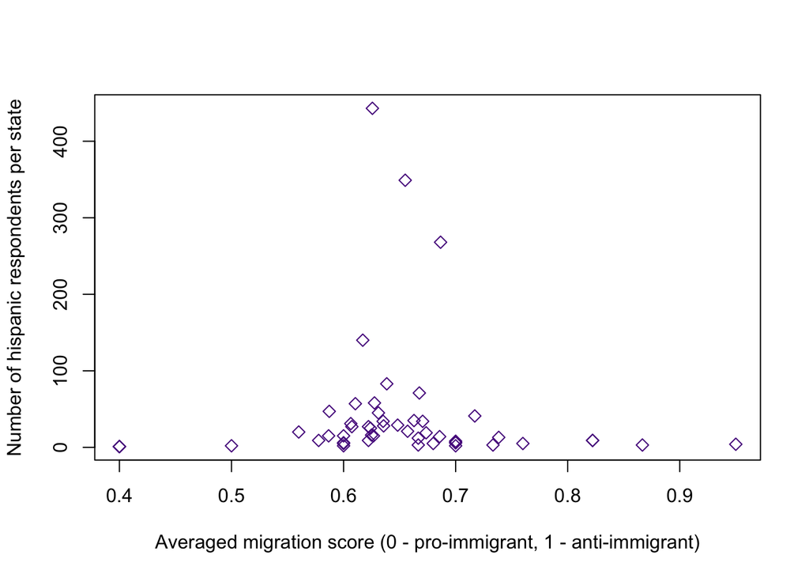

```r
plot(hisp_imm_states$avg.immigr, hisp_imm_states$race, pch = 5, col = "purple4",
     ylab = "Number of hispanic respondents per state",
     xlab = "Averaged migration score (0 - pro-immigrant, 1 - anti-immigrant)")
```

According to distribution of the data shown on the plot above, we can see that a big number of hispanic residents in the state does not necessarily lead to very strong pro-immigrant or anti-immigrant attitudes - most datapoints are concentrated closer to the middle of the score.